# skl_nonlinear regression

```python
import numpy as np
import matplotlib.pyplot as plt
import seaborn as sns

%matplotlib inline
```

```python
#seaborn設定
sns.set()
#背景変更
sns.set_style("darkgrid", {'grid.linestyle': '--'})
#大きさ(スケール変更)
sns.set_context("paper")
```

```python
n=100

def true_func(x):
    z = 1-48*x+218*x**2-315*x**3+145*x**4
    return z

def linear_func(x):
    z = x
    return z
```

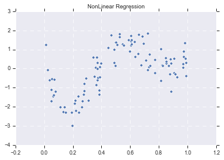

```python
# 真の関数からノイズを伴うデータを生成

# 真の関数からデータ生成
data = np.random.rand(n).astype(np.float32)
data = np.sort(data)
target = true_func(data)

# 　ノイズを加える
noise = 0.5 * np.random.randn(n)
target = target  + noise

# ノイズ付きデータを描画

plt.scatter(data, target)

plt.title('NonLinear Regression')
plt.legend(loc=2)
```

```
0.28335411637721486
```

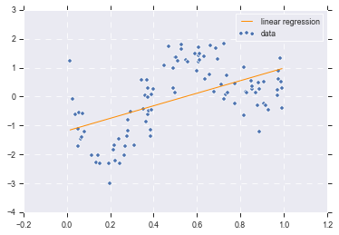

```python
from sklearn.linear_model import LinearRegression

clf = LinearRegression()
data = data.reshape(-1,1)
target = target.reshape(-1,1)
clf.fit(data, target)

p_lin = clf.predict(data)

plt.scatter(data, target, label='data')
plt.plot(data, p_lin, color='darkorange', marker='', linestyle='-', linewidth=1, markersize=6, label='linear regression')
plt.legend()
print(clf.score(data, target))
```

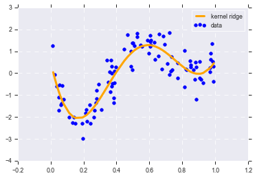

```python
from sklearn.kernel_ridge import KernelRidge

clf = KernelRidge(alpha=0.0002, kernel='rbf')
clf.fit(data, target)

p_kridge = clf.predict(data)

plt.scatter(data, target, color='blue', label='data')

plt.plot(data, p_kridge, color='orange', linestyle='-', linewidth=3, markersize=6, label='kernel ridge')
plt.legend()
#plt.plot(data, p, color='orange', marker='o', linestyle='-', linewidth=1, markersize=6)
```

```
0.7603418518573869
```

[figure not shown]

```python
#Ridge

from sklearn.metrics.pairwise import rbf_kernel
from sklearn.linear_model import Ridge

kx = rbf_kernel(X=data, Y=data, gamma=50)
#KX = rbf_kernel(X, x)

#clf = LinearRegression()
clf = Ridge(alpha=30)
clf.fit(kx, target)

p_ridge = clf.predict(kx)

plt.scatter(data, target,label='data')
for i in range(len(kx)):
    plt.plot(data, kx[i], color='black', linestyle='-', linewidth=1, markersize=3, label='rbf', alpha=0.2)

#plt.plot(data, p, color='green', marker='o', linestyle='-', linewidth=0.1, markersize=3)
plt.plot(data, p_ridge, color='green', linestyle='-', linewidth=1, markersize=3,label='ridge regression')
#plt.legend()

print(clf.score(kx, target))
```

```python
from sklearn.preprocessing import PolynomialFeatures
from sklearn.pipeline import Pipeline
```

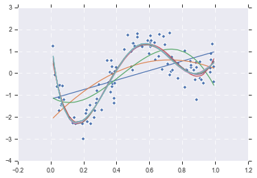

```python
#PolynomialFeatures(degree=1)

deg = [1,2,3,4,5,6,7,8,9,10]
for d in deg:
    regr = Pipeline([
        ('poly', PolynomialFeatures(degree=d)),
        ('linear', LinearRegression())
    ])
    regr.fit(data, target)
    # make predictions
    p_poly = regr.predict(data)
    # plot regression result
    plt.scatter(data, target, label='data')
    plt.plot(data, p_poly, label='polynomial of degree %d' % (d))
```

```
-4.440892098500626e-16
```

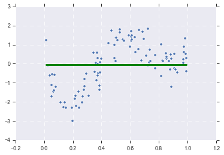

```python
#Lasso

from sklearn.metrics.pairwise import rbf_kernel
from sklearn.linear_model import Lasso

kx = rbf_kernel(X=data, Y=data, gamma=5)
#KX = rbf_kernel(X, x)

#lasso_clf = LinearRegression()
lasso_clf = Lasso(alpha=10000, max_iter=1000)
lasso_clf.fit(kx, target)

p_lasso = lasso_clf.predict(kx)

plt.scatter(data, target)

#plt.plot(data, p, color='green', marker='o', linestyle='-', linewidth=0.1, markersize=3)
plt.plot(data, p_lasso, color='green', linestyle='-', linewidth=3, markersize=3)

print(lasso_clf.score(kx, target))
```

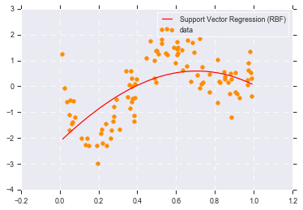

```python
from sklearn import cross_validation, preprocessing, linear_model, svm

# SVR-rbf
clf_svr = svm.SVR(kernel='rbf', C=1e3, gamma=0.1, epsilon=0.1)
clf_svr.fit(data, target)
y_rbf = clf_svr.fit(data, target).predict(data)

# plot

plt.scatter(data, target, color='darkorange', label='data')
plt.plot(data, y_rbf, color='red', label='Support Vector Regression (RBF)')
plt.legend()
plt.show()
```

```python
from sklearn.model_selection import train_test_split
x_train, x_test, y_train, y_test = train_test_split(data, target, test_size=0.1, random_state=0)
```

```python
from keras.callbacks import EarlyStopping, TensorBoard, ModelCheckpoint

#cb_cp = ModelCheckpoint('./out/checkpoints/weights.{epoch:02d}-{val_loss:.2f}.hdf5', verbose=1, save_weights_only=True)
cb_cp = ModelCheckpoint('./weights.{epoch:02d}-{val_loss:.2f}.hdf5', verbose=1, save_weights_only=True)

cb_tf  = TensorBoard(log_dir='./out/tensorBoard', histogram_freq=0)
```

```python
from keras.models import Sequential
from keras.layers import Input, Dense, Dropout, BatchNormalization
from keras.wrappers.scikit_learn import KerasRegressor

def relu_reg_model():
    model = Sequential()
    model.add(Dense(10, input_dim=1, activation='relu'))
    model.add(Dense(1000, activation='relu'))
    model.add(Dense(1000, activation='relu'))
    model.add(Dense(1000, activation='linear'))
    model.add(Dense(1))

    model.compile(loss='mean_squared_error', optimizer='adam')
    return model

# use data split and fit to run the model
estimator = KerasRegressor(build_fn=relu_reg_model, epochs=100, batch_size=5, verbose=1)

history = estimator.fit(x_train, y_train, callbacks=[cb_cp, cb_tf], validation_data=(x_test, y_test))
```

[output not shown]

[output cut: 146 more lines]

```
Epoch 00093: saving model to ./weights.93-0.35.hdf5

Epoch 00094: saving model to ./weights.94-0.49.hdf5

Epoch 00095: saving model to ./weights.95-0.42.hdf5

Epoch 00096: saving model to ./weights.96-0.43.hdf5

Epoch 00097: saving model to ./weights.97-0.38.hdf5

Epoch 00098: saving model to ./weights.98-0.56.hdf5

Epoch 00099: saving model to ./weights.99-0.36.hdf5

Epoch 00100: saving model to ./weights.100-0.44.hdf5
```

```python
y_pred = estimator.predict(x_train)
```

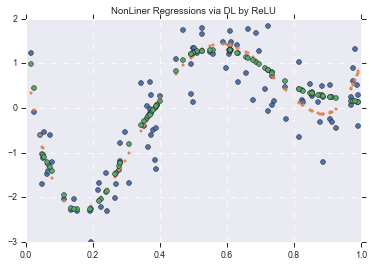

```python
plt.title('NonLiner Regressions via DL by ReLU')
plt.plot(data, target, 'o')
plt.plot(data, true_func(data), '.')
plt.plot(x_train, y_pred, "o", label='predicted: deep learning')
#plt.legend(loc=2)
```

```python
print(lasso_clf.coef_)
```

```
[-0. -0. -0. -0. -0. -0. -0. -0. -0. -0. -0. -0. -0. -0. -0. -0. -0. -0.
 -0. -0. -0. -0. -0. -0. -0. -0. -0. -0. -0. -0. -0. -0. -0. -0. -0. -0.
 -0.  0.  0.  0.  0.  0.  0.  0.  0.  0.  0.  0.  0.  0.  0.  0.  0.  0.
  0.  0.  0.  0.  0.  0.  0.  0.  0.  0.  0.  0.  0.  0.  0.  0.  0.  0.
  0.  0.  0.  0.  0.  0.  0.  0.  0.  0.  0.  0.  0.  0.  0.  0.  0.  0.
  0.  0.  0.  0.  0.  0.  0.  0.  0.  0.]
```

# 考察

RidgeやLassoのアルファを変えて実験して見た。  
講義でも話していたように下記の働きがあることを確認した。  
・Ridge : パラメータ全体の総量を低く抑える働き  
・Lasso : パラメータを減らす(次元圧縮)の働き

RidgeやLassoのパラメータで実験をして思ったことが下記。  
RidgeやLassoのパラメータも学習前は決めるパラメータである。  
決定されたパラメータを用いて学習された結果、たまたま良い精度が出る可能性がある。  
もう少し言うと、その学習データと検証用データにたまたまフィットしただけかもしれない。  
そのため、学習用データと検証用データの他にもう一つ検証用が必要になってくるのではないかと思う。  
⇨クロスバリデーションをした後に、さらに検証用データでテストして見る。

パラメータの決定方法が非常に難しいと感じた。  
データ数も大事であるが、データ分割の仕方も大事であるし、そのデータの質が良いものかどうか、意味のないデータは消すなど。。。  
さらに、過学習・見学習してないかの確認等々。。。  
機械学習や深層学習で一番かかるのが学習前の処理や検証であるなと強く感じた。

あと次元圧縮としては、Lassoと主成分分析(又は固有値分解)ではどちらを使うべきなのだろうか？？？(時間があるときに考えて見る)

```
0.05365999026569579
```

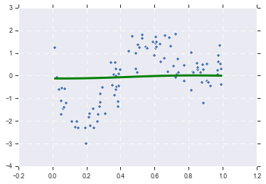

```python
#Ridge

from sklearn.metrics.pairwise import rbf_kernel
#from sklearn.linear_model import Lasso
from sklearn.linear_model import Ridge

kx = rbf_kernel(X=data, Y=data, gamma=5)
#KX = rbf_kernel(X, x)

#lasso_clf = LinearRegression()
#lasso_clf = Lasso(alpha=10000, max_iter=1000)
lasso_clf = Ridge(alpha=10000)
lasso_clf.fit(kx, target)

p_lasso = lasso_clf.predict(kx)

plt.scatter(data, target)

#plt.plot(data, p, color='green', marker='o', linestyle='-', linewidth=0.1, markersize=3)
plt.plot(data, p_lasso, color='green', linestyle='-', linewidth=3, markersize=3)

print(lasso_clf.score(kx, target))
```

```python
print(lasso_clf.coef_)
```

```
[[-0.00251065 -0.00252477 -0.00254038 -0.00254484 -0.00254517 -0.00254608
  -0.00254561 -0.0025446  -0.00254215 -0.00253701 -0.00248057 -0.00241356
  -0.00238281 -0.00235595 -0.00214781 -0.00212707 -0.00200369 -0.00198188
  -0.00193481 -0.00181523 -0.00180062 -0.00159241 -0.00157494 -0.00148076
  -0.00144728 -0.0014443  -0.00132658 -0.00118558 -0.00081625 -0.00070277
  -0.00063096 -0.00057866 -0.00052947 -0.00049973 -0.00048661 -0.00048516
  -0.00041471 -0.00035731 -0.00032458 -0.00030919 -0.00027427 -0.00017722
   0.00036657  0.00061354  0.00085563  0.00085742  0.00092028  0.00092192
   0.00096821  0.00106328  0.00120242  0.00121675  0.0014179   0.00150363
   0.00175071  0.0018123   0.00187923  0.00189282  0.00189712  0.00190959
   0.00191172  0.00203927  0.00205778  0.00217881  0.00219878  0.0022613
   0.00229796  0.00232721  0.00237469  0.00239529  0.00239565  0.00241436
   0.00241805  0.00242578  0.00244274  0.00244254  0.00240919  0.00240781
   0.0023951   0.00239104  0.00234217  0.00233124  0.00232997  0.00228193
   0.00225552  0.00224068  0.00223535  0.00223422  0.00215648  0.00215105
   0.00213164  0.0020809   0.00189874  0.00189201  0.00187018  0.0018636
   0.00184248  0.00181251  0.00180167  0.00179142]]
```

```
-4.440892098500626e-16
```

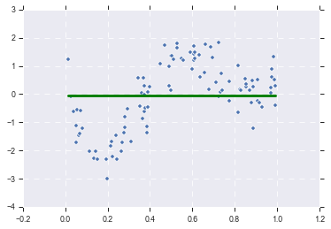

```python
#lasso

from sklearn.metrics.pairwise import rbf_kernel
from sklearn.linear_model import Lasso
#from sklearn.linear_model import Ridge

kx = rbf_kernel(X=data, Y=data, gamma=5)
#KX = rbf_kernel(X, x)

#lasso_clf = LinearRegression()
lasso_clf = Lasso(alpha=10000, max_iter=1000)
#lasso_clf = Ridge(alpha=10000)
lasso_clf.fit(kx, target)

p_lasso = lasso_clf.predict(kx)

plt.scatter(data, target)

#plt.plot(data, p, color='green', marker='o', linestyle='-', linewidth=0.1, markersize=3)
plt.plot(data, p_lasso, color='green', linestyle='-', linewidth=3, markersize=3)

print(lasso_clf.score(kx, target))
```

```python
print(lasso_clf.coef_)
```

```
[-0. -0. -0. -0. -0. -0. -0. -0. -0. -0. -0. -0. -0. -0. -0. -0. -0. -0.
 -0. -0. -0. -0. -0. -0. -0. -0. -0. -0. -0. -0. -0. -0. -0. -0. -0. -0.
 -0. -0. -0. -0. -0. -0.  0.  0.  0.  0.  0.  0.  0.  0.  0.  0.  0.  0.
  0.  0.  0.  0.  0.  0.  0.  0.  0.  0.  0.  0.  0.  0.  0.  0.  0.  0.
  0.  0.  0.  0.  0.  0.  0.  0.  0.  0.  0.  0.  0.  0.  0.  0.  0.  0.
  0.  0.  0.  0.  0.  0.  0.  0.  0.  0.]
```